# presentation-live

## Mají tučňáci s delší ploutví také vyšší tělesnou hmotnost?

BIOSTATISTIKA

L02

Vztahy dvou proměnných a vizualizace

cuni-natur-biostatistics.github.io/materialy.html

## Pomůže nám druhá proměnná?

Naše biologická otázka Mají tučňáci s delší ploutví také vyšší tělesnou hmotnost?

Ilustrace: [Allison Horst](https://allisonhorst.com/)

## Co si pamatujete z minulé lekce?

Odpovězte samostatně na tři krátké otázky. Potom společně projdeme správné odpovědi.

## Který z uvedených druhů spí podle tabulky nejdéle?

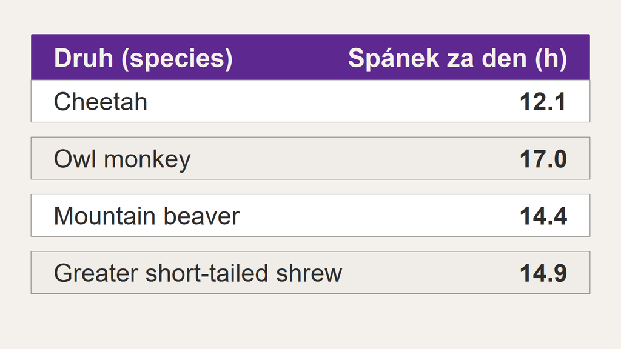

- Cheetah
- Owl monkey
- Mountain beaver
- Greater short-tailed shrew

Správná odpověď: Owl monkey

Porovnáme hodnoty ve sloupci Spánek za den (h). Nejvyšší hodnota je 17.0 h v řádku Owl monkey.

## Ve kterém intervalu délky spánku je podle histogramu nejvíce zastoupených druhů?

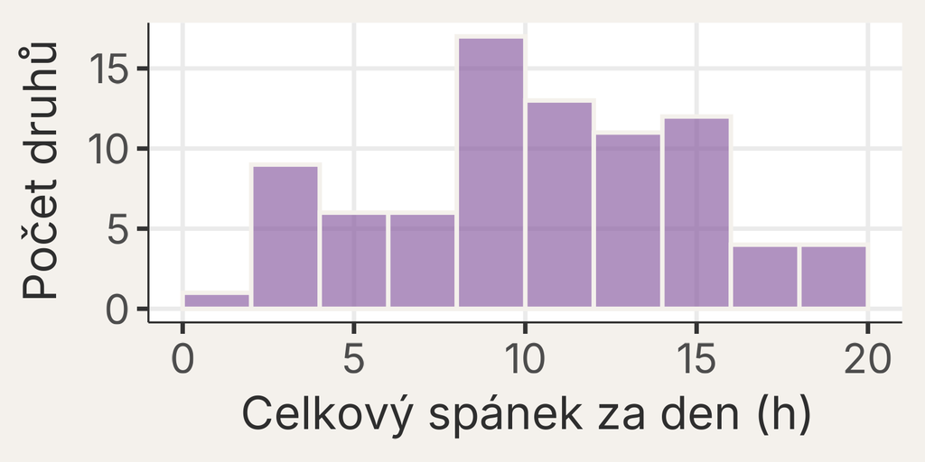

- 10–12 h
- 12–14 h
- 8–10 h
- 16–18 h

Správná odpověď: 8–10 h

Nejvyšší sloupec stojí nad intervalem 8–10 h. Poloha sloupce na vodorovné ose určuje interval spánku; jeho výška vyjadřuje počet druhů v tomto intervalu.

## Jaká je podle výstupu průměrná délka spánku devíti druhů?

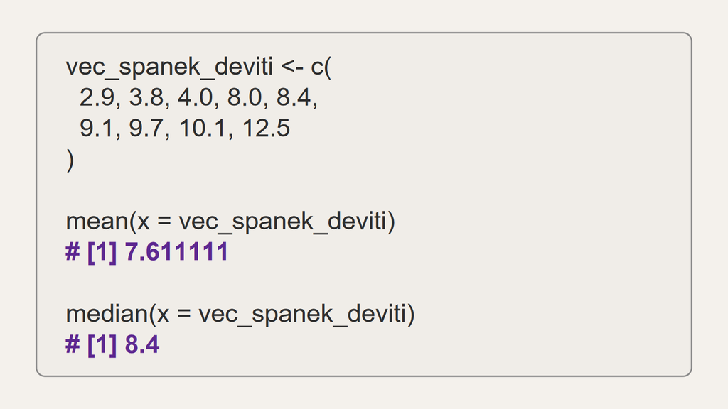

- 7.611111 h
- 8.4 h
- 4.0 h
- 9.1 h

Správná odpověď: 7.611111 h

Průměr vypočítává funkce mean(), která vrací 7.611111 h. Funkce median() vrací 8.4 h; hodnoty 4.0 h a 9.1 h jsou jednotlivá pozorování ve vektoru.

## Výsledky učení

Po dnešní přednášce budete schopni:

- přečíst první bodový graf pro dvě numerické proměnné
- vysvětlit, co nám ukáže rozptyl a co přidá korelace
- zvolit vhodný první graf podle typu dvojice proměnných
- rozlišit mezi viditelným vzorem v datech a silnějším tvrzením o efektu

## Od jedné proměnné ke dvěma

V minulé lekci jsme četli jednu proměnnou

Z tabulky, histogramu nebo číselného souhrnu jsme zjišťovali, jak vypadají hodnoty jedné proměnné.

Dnes musíme zachovat dvojice

Jak zobrazíme délku ploutve a hmotnost tak, aby bylo vidět, které dvě hodnoty patří stejnému tučňákovi?

## Dvě hodnoty patří jednomu tučňákovi

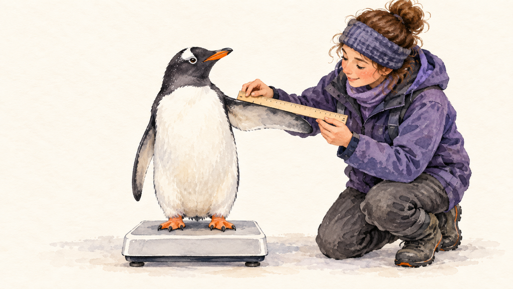

Ilustrační obraz vytvořen AI.

Dvojice měření musí zůstat spojena se stejným pozorováním.

## Diskuze se sousedem

Naše biologická otázka Mají tučňáci s delší ploutví také vyšší tělesnou hmotnost?

Jak by podle vás mohl vypadat graf pro zodpovězení této otázky?

*30 s přemýšlení — pak sdílejte svůj odhad se sousedem.*

## Naše data

```r
vec_delka_ploutve_mm <-
  c(
    186, # tučňák 1
    191 # tučňák 2
  )

vec_hmotnost_g <-
  c(
    3800, # tučňák 1
    3920 # tučňák 2
  )

plot(
  x = vec_delka_ploutve_mm,
  y = vec_hmotnost_g,
  xlab = "Délka ploutve (mm)",
  ylab = "Tělesná hmotnost (g)",
  pch = 16
)
```

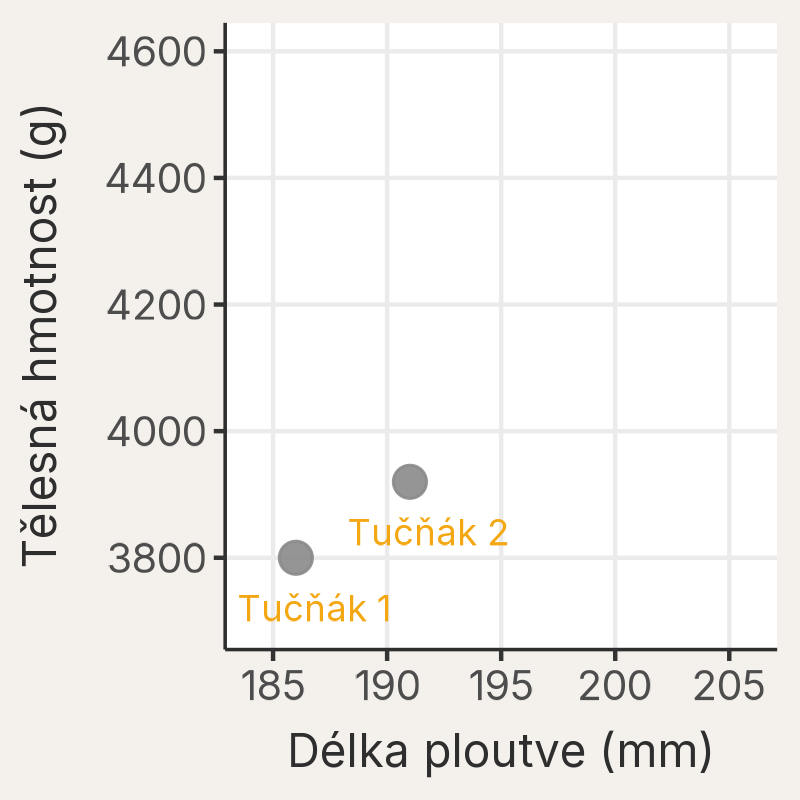

## Naše data

```r
vec_delka_ploutve_mm <-
  c(
    186, # tučňák 1
    191, # tučňák 2
    197, # tučňák 3
    204 # tučňák 4
  )

vec_hmotnost_g <-
  c(
    3800, # tučňák 1
    3920, # tučňák 2
    4300, # tučňák 3
    4480 # tučňák 4
  )

plot(
  x = vec_delka_ploutve_mm,
  y = vec_hmotnost_g,
  xlab = "Délka ploutve (mm)",
  ylab = "Tělesná hmotnost (g)",
  pch = 16
)
```

[output not shown]

## Naše data

```r
plot(
  x = data_tucnaci$delka_ploutve_mm,
  y = data_tucnaci$hmotnost_g,
  xlab = "Délka ploutve (mm)",
  ylab = "Tělesná hmotnost (g)",
  pch = 16
)
```

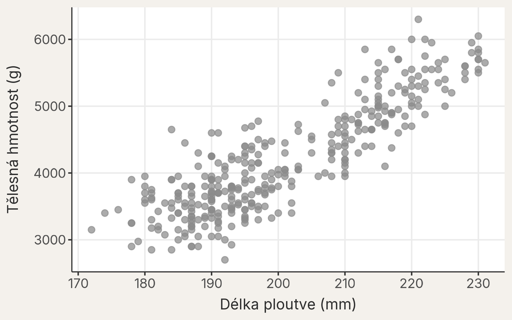

## Co už v tomto grafu vidíme?

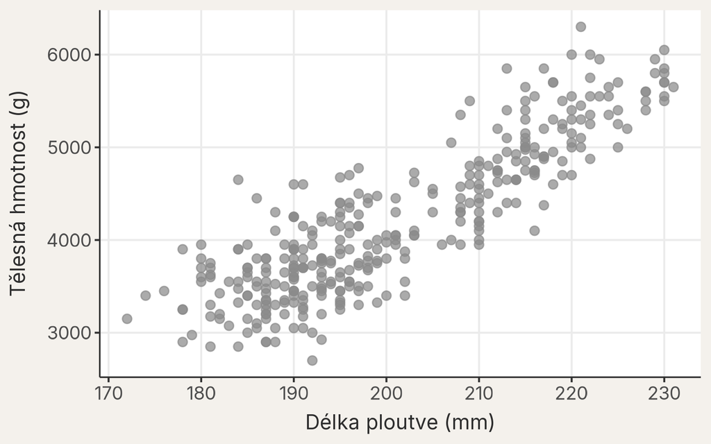

- Směr: rostoucí
- Rozptyl: pořád široký
- Závěr: vzor vidíme, efekt zatím netvrdíme

## Stejná data, jiné osy

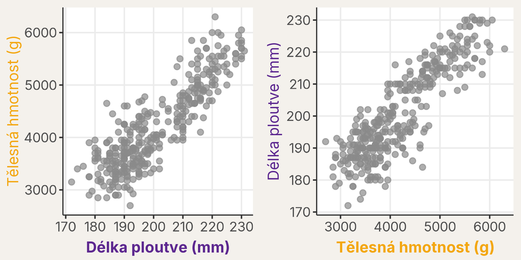

Délka ploutve na ose x

Hmotnost na ose x

## Rozptyl čteme ve dvou směrech

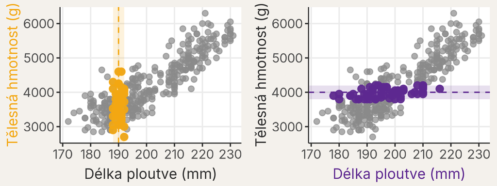

Podobná délka ploutve, různá hmotnost

Podobná hmotnost, různá délka ploutve

Když čteme bodový graf, díváme se současně na směr vztahu i na to, jak široký oblak zůstává v obou směrech.

## Vracíme se k biologické otázce

*Mají tučňáci s delší ploutví také vyšší tělesnou hmotnost?*

Signál

Delší ploutve **bývají spojeny** s vyšší hmotností.

Rozptyl

Vztah **není** dokonale těsný.

POZOR Vzor v grafu ještě není model, efekt ani nejistota.

Co už můžeme tvrdit?

Která formulace je v této chvíli nejlepší?

1. V grafu je vidět vztah, takže jsme prokázali efekt.
2. V datech je vidět biologicky smysluplný vzor, který chceme popsat přesněji.
3. Protože body neleží na jedné přímce, mezi proměnnými žádný vztah není.

Než hlasujeme: přesvědčte souseda, proč jste vybrali svoji možnost.

## Stejná data, ale s druhem

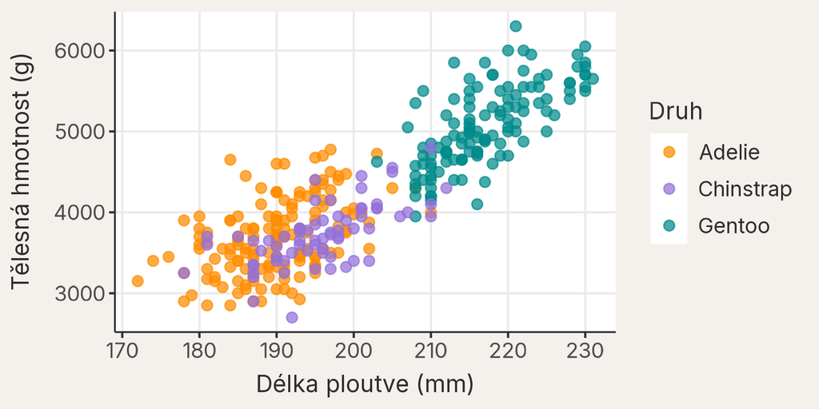

## Co se po obarvení změnilo?

Biologická logika platí i po obarvení podle druhu

- Směr oblaku zůstává kladný
  - *větší tučňák má delší ploutev*.
- Rozptyl má biologickou strukturu
  - Část variability pochází z míchání více druhů

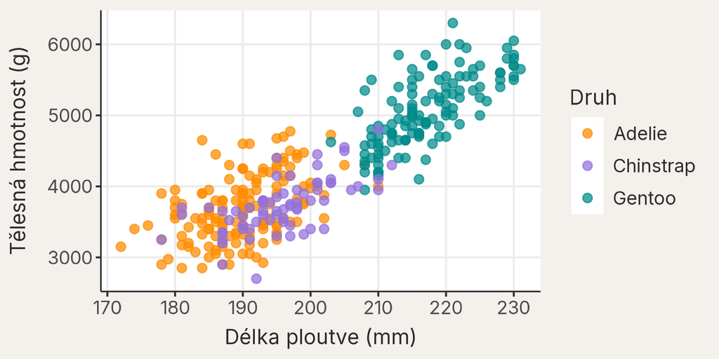

## Kdybychom chtěli jedno číslo pro souhrn všech dat?

Co by takové číslo muselo umět?

Směr + těsnost + stejné měřítko pro různé jednotky

Řekněte sousedovi aspoň jednu vlastnost

30 s každý — pak porovnejte, co jste vymysleli.

# Kovariance

## Nejprve průmery grafu

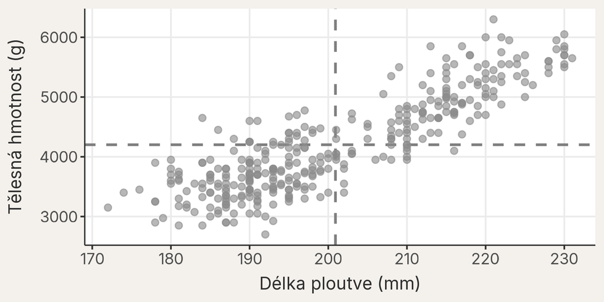

Střed grafu určíme dvěma průměry: délka 200.9 mm, hmotnost 4202 g.

## Jeden bod pod lupou

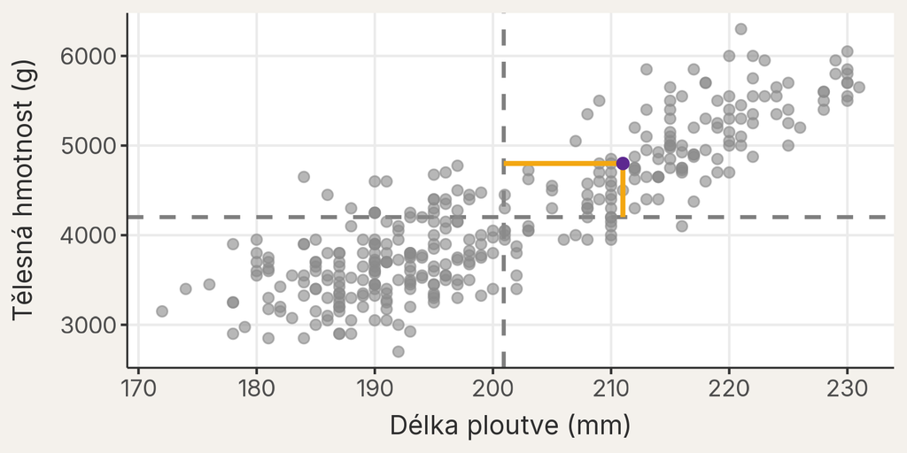

Bod nad průměrem v obou proměnných

Stejné znaménko odchylek -> **kladný** příspěvek.

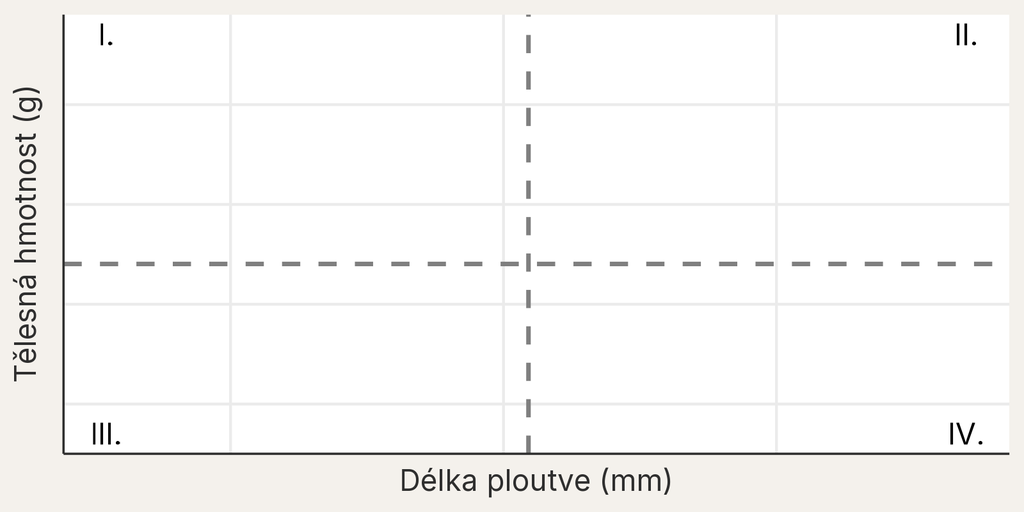

## Ve které další části grafu budou součiny také kladné?

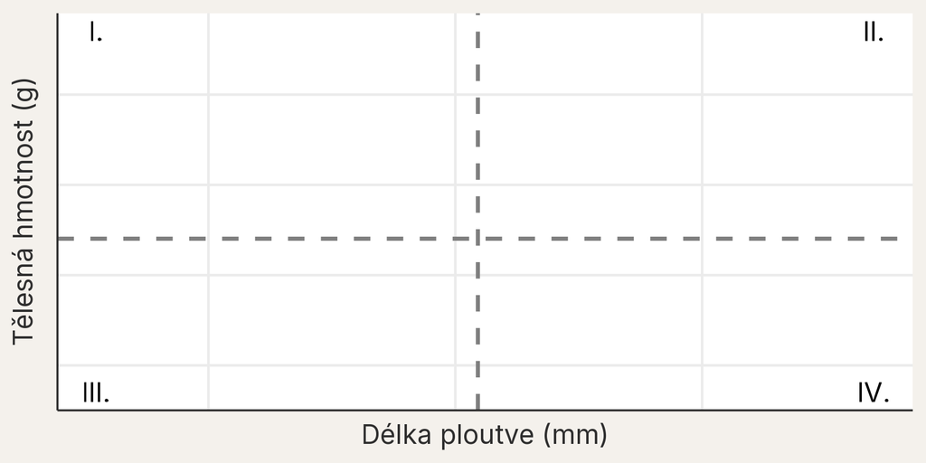

II. a III. kvadrant

Vpravo nahoře a vlevo dole — obě odchylky mají vždy stejné znaménko.

I. a IV. kvadrant

Vlevo nahoře a vpravo dole — odchylky mají opačná znaménka.

Všechny čtyři stejně

Na poloze vůči středu nezáleží.

Než hlasujeme: vysvětlete sousedovi znaménka obou odchylek v jedné možnosti.

## Projdeme čtyři tučňáky ručně

Průměry:

Délka ploutve: **194.5** mm

Hmotnost: **4125** g

| Délka | Hmotnost | Délka odch. | Hmotnost odch. |
| --- | --- | --- | --- |
| 186 | 3800 | -8.5 | -325 |
| 191 | 3920 | -3.5 | -205 |
| 197 | 4300 | 2.5 | 175 |
| 204 | 4480 | 9.5 | 355 |

## Kovariance je “průměr součinů odchylek”

kovariance = **součet součinů odchylek** / (**počet pozorování** - 1)

Kovariance sčítá, jestli body leží převážně v kladných nebo záporných částech grafu.

| Délka odch. | Hmotnost odch. | Součin |
| --- | --- | --- |
| -8.5 | -325 | 2762.5 |
| -3.5 | -205 | 717.5 |
| 2.5 | 175 | 437.5 |
| 9.5 | 355 | 3372.5 |

součet součinů odchylek = 7290

počet pozorování - 1 = 3

kovariance = 7290 / 3 = **2430 mm·g**

## Prakticky stejné číslo nám dá funkce `cov()`.

```r
soucin <- sum(
  data_priklad_vztahu_kovariance$soucin_odchylek
)
pocet_pozorovani_minus_one <-
  nrow(data_priklad_vztahu_kovariance) - 1
kovariance <-
  vec_soucin / pocet_pozorovani_minus_one
kovariance
```

```r
kovariance <- cov(
  x = data_priklad_vztahu_kovariance$delka_ploutve_mm,
  y = data_priklad_vztahu_kovariance$hmotnost_g
)
kovariance
```

[1] 2430

## Záleží na jednotkách?

Stejní tučňáci. Jiná jednotka.

V milimetrech a gramech

Kovariance: 9 824 (mm·g)

V centimetrech a kilogramech

Kovariance: 0,982 (cm·kg)

Směr vztahu se nezměnil, ale číslo ano. Proto chceme bezrozměrný souhrn: korelaci.

# Korelace

## Dvě čísla, která budeme používat

Pearsonova korelace

- shrnuje lineární vztah
- bezrozměrná, v rozsahu −1 až 1
- `cor(..., method = "pearson")`

Spearmanova korelace

- sleduje pořadí hodnot (rank)
- odolnější vůči zakřivení a odlehlým bodům
- `cor(..., method = "spearman")`

Obě čísla jsou doplněk ke grafu, ne jeho náhrada.

## Kalibrační galerie

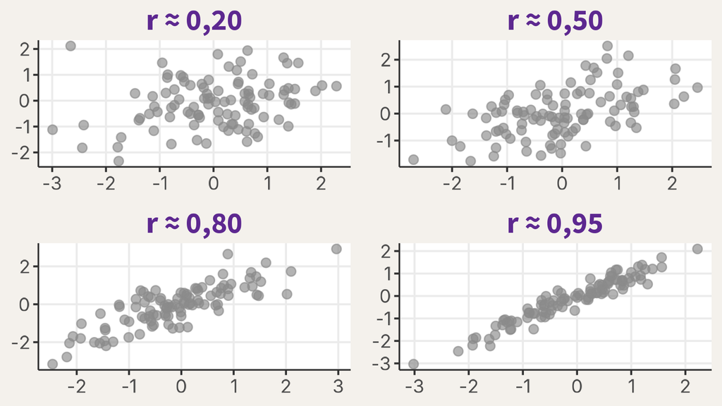

Naše tučňáci: r = **0,87**

## Záporná korelace

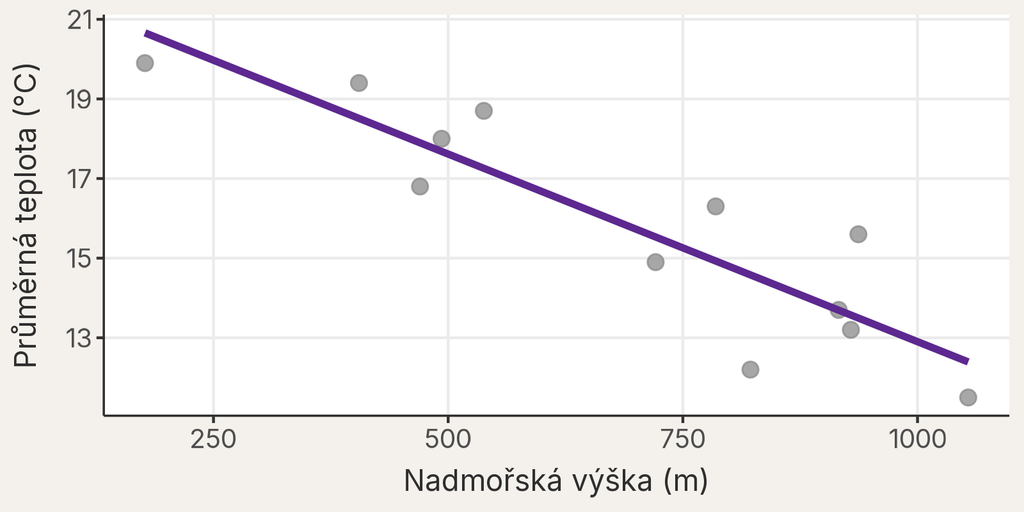

Záporné r (-0,89) | vyšší nadmořská výška → nižší průměrná teplota.

## Čtyři tučňáci v kódu

```r
vec_delka_ploutve_mm <-
  c(186, 191, 197, 204)

vec_hmotnost_g <-
  c(3800, 3920, 4300, 4480)

cor(
  x = vec_delka_ploutve_mm,
  y = vec_hmotnost_g,
  method = "pearson"
)

cor(
  x = vec_delka_ploutve_mm,
  y = vec_hmotnost_g,
  method = "spearman"
)
```

Výstup

Pearson: [1] 0,98  
Spearman: [1] 1,00

## Všichni tučňáci v kódu

Pearsonova korelace

```r
cor(
  x = data_tucnaci$delka_ploutve_mm,
  y = data_tucnaci$hmotnost_g,
  method = "pearson"
)
```

Výstup

[1] 0,87

Spearmanova korelace

```r
cor(
  x = data_tucnaci$delka_ploutve_mm,
  y = data_tucnaci$hmotnost_g,
  method = "spearman"
)
```

Výstup

[1] 0,84

Pearson zdůrazňuje linearitu, Spearman pořadí hodnot.

Ve které ze čtyř situací by se hodnoty Pearsona a Spearmana lišily nejvíce?

Silný lineární vztah

Obě čísla by se shodla — vztah je přímočarý.

Žádná zřetelná souvislost

Obě čísla by byla nízká.

Monotónní, ale zakřivený vztah

Pořadí sedí, ale linearita ne.

Než hlasujeme: přesvědčte souseda, která situace nejvíc rozdělí Pearsona a Spearmana.

## Příklad

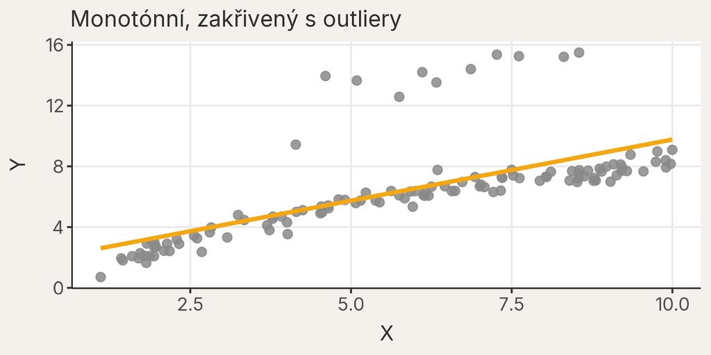

Pearson: 0,67 / Spearman: 0,86 — pořadí sedí, ale linearita ne úplně.

## Čtyři situace korelace

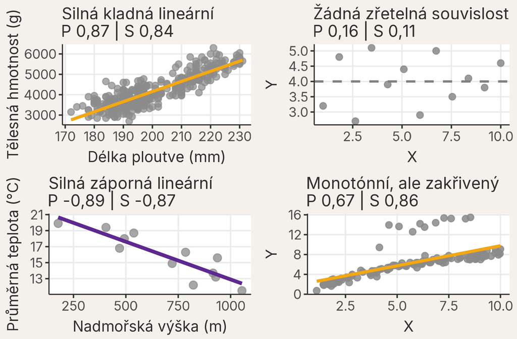

## Co nám to říká právě o tučňácích?

*Mají tučňáci s delší ploutví také vyšší tělesnou hmotnost?*

Pearson i Spearman vyšly podobně

Pearson: 0,87, Spearman: 0,84.

Vztah je rostoucí a dobře shrnutelný jedním číslem.

Korelace neřekne, odkud vztah pochází

Část vztahu může souviset s druhem nebo celkovou velikostí těla.

## Korelace není kauzalita

[figure not shown]

## Korelace ukazuje asociaci, ne příčinu

Společná změna dvou proměnných

Korelace popisuje, zda se dvě proměnné mění společně.

Sama neoddělí příčinu

Korelace sama neodliší přímý efekt od sdílené příčiny.

# Jak vybrat první graf?

## Tři dvojice, tři různé otázky

Délka ploutve × hmotnost

Druh tučňáka × hmotnost

Druh tučňáka × ostrov

Skupinka 3–4 · 2 min

Ke každé dvojici navrhněte první graf a jednou větou zdůvodněte, co z něj chcete přečíst.

## Rozhodovací mapa

| Proměnná A | Proměnná B | První poctivý pohled | Co z něj čteme |
| --- | --- | --- | --- |
| kvantitativní | kvantitativní | bodový graf | směr, tvar, těsnost, odlehlé body |
| kvantitativní | kategoriální | body ve skupinách; boxplot + body | rozdíly a překryv rozdělení |
| kategoriální | kategoriální | tabulka nebo sloupce počtů/podílů | složení kombinací kategorií |

Typy proměnných zúží možnosti. Biologická otázka rozhodne, co má graf zvýraznit.

## Tři první pohledy

Dvě hodnoty

**Body:** jaký je směr, tvar a rozptyl?

Hodnota a skupina

**Body + souhrn:** jak se skupiny liší a překrývají?

Dvě skupiny

**Počty nebo podíly:** kterou informaci potřebujeme?

Co nesmíme skrýt?

Boxplot může skrýt tvar a velikost vzorku. Podíly mohou skrýt počty. Hezčí graf proto není automaticky poctivější první graf.

# Jak vybrat první graf?

## Typy proměnných zúží volbu grafu

Délka ploutve × hmotnost

Druh tučnáka × hmotnost

Druh tučnáka × ostrov (habitat)

Skupinka 3-4 - 2 min

Ke každé dvojici přiřaďte graf a připravte si jedno zdůvodnění.

## Kvantitativní × kvantitativní

Délka ploutve × hmotnost

Obě proměnné mají číselnou osu. Každý jedinec může být jedním bodem.

## K×K: body

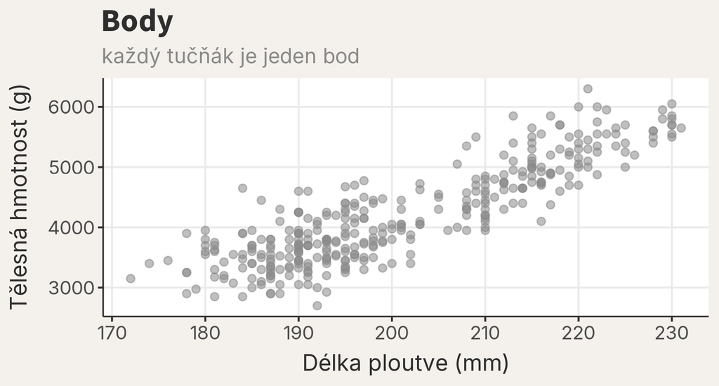

Když mají obě proměnné číselné hodnoty, první volbou je bodový graf.

## K×K: přidáme kategorii barvou

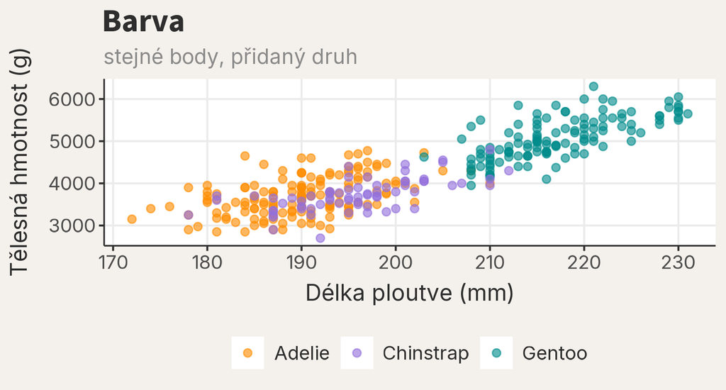

Barva nepřidala novou osu. Přidala novou otázku: je vztah stejný ve všech skupinách?

## K×K: když se body překrývají

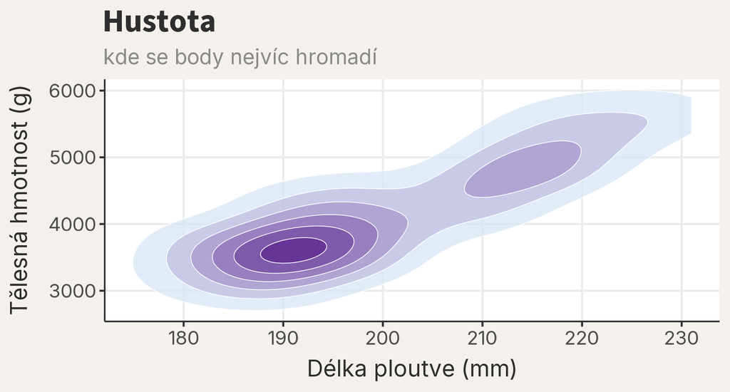

Hustota odpovídá na jinou otázku: kde je dat nejvíc?

## K×K: zvolte první graf

První čtení

Co ukážu, když chci vztah nejdřív jen vidět?

Skupiny

Co přidám, když podezírám rozdíly mezi druhy?

Překryv

Co změním, když mám tisíce bodů?

## Kvantitativní × kategoriální

Hmotnost × druh

Jedna proměnná je číslo, druhá vytváří skupiny. Už nečteme oblak bodů ve dvou číselných osách.

## K×Kat: body ve skupinách

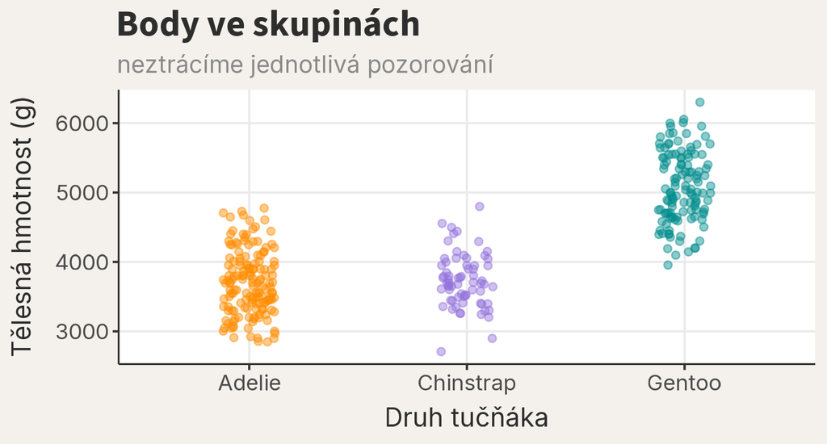

Body ve skupinách jsou často nejlepší první graf, protože nic neskrývají.

## K×Kat: boxplot + body

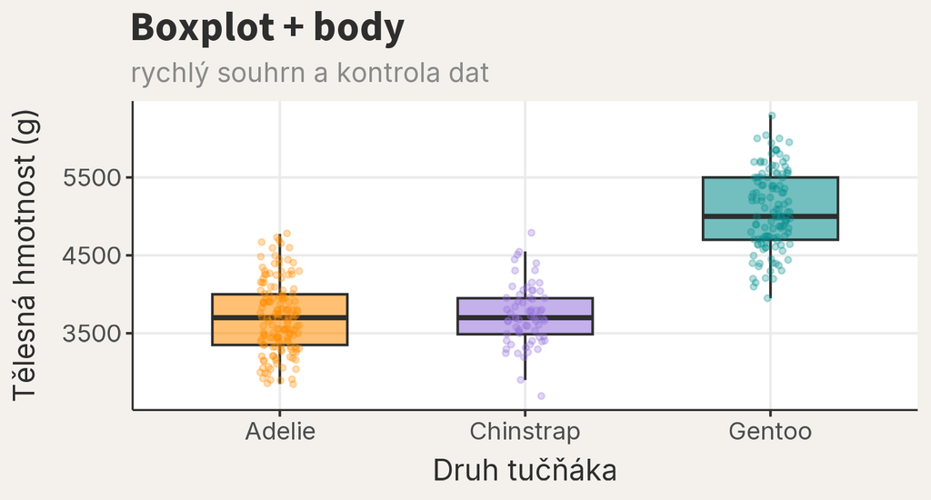

Boxplot je rychlý souhrn, ale samotný boxplot může skrýt tvar dat.

## K×Kat: violin + boxplot

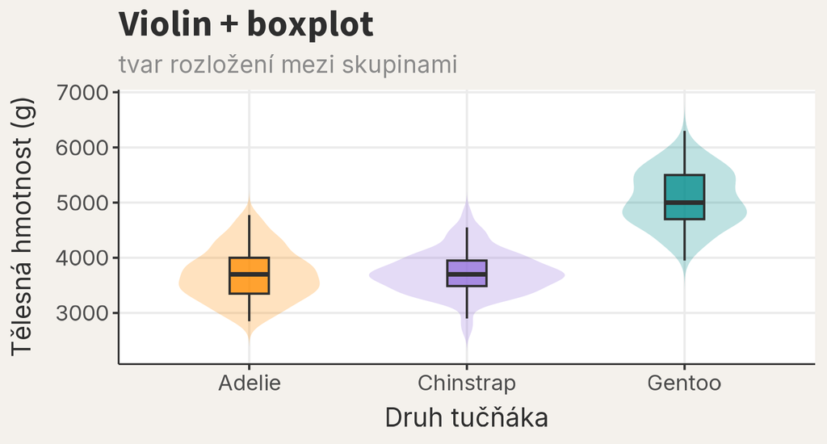

Violin ukáže tvar rozložení; boxplot uvnitř dá rychlý souhrn.

## K×Kat: histogram

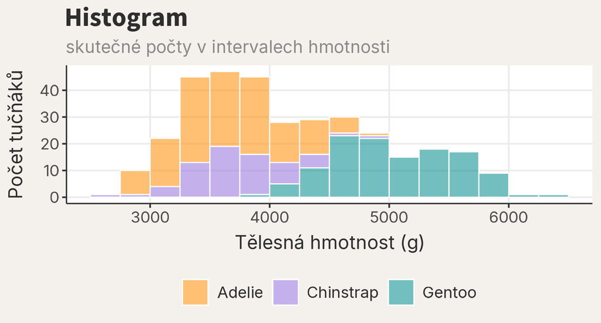

Histogram ukazuje skutečné počty tučňáků v intervalech hmotnosti.

## K×Kat: skládaná hustota

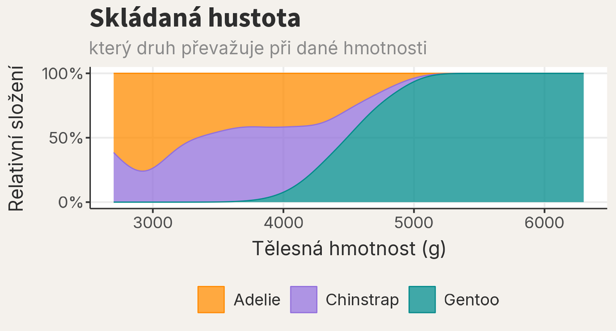

Skládaná hustota neukazuje počty. Ukazuje relativní složení druhů podél hmotnosti.

## Který graf byste udělali jako první?

Body ve skupinách

Vidíme každého tučňáka.

Boxplot

Rychleji čteme typickou hodnotu a rozptyl.

Violin / histogram

Lépe čteme tvar nebo počty v intervalech.

## Kategoriální × kategoriální

Druh × ostrov

Obě proměnné jsou skupiny. Teď čteme počty nebo podíly v kombinacích kategorií.

## Kat×Kat: waffle plot

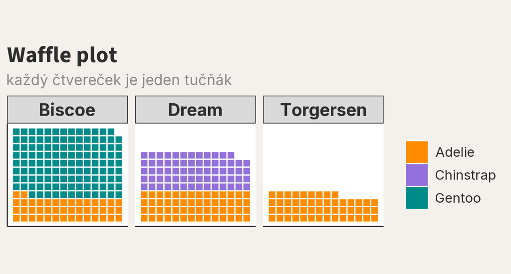

Waffle plot ukáže počty jako jednotky: vidíme složení i velikost skupin.

## Kat×Kat: skupinové sloupce

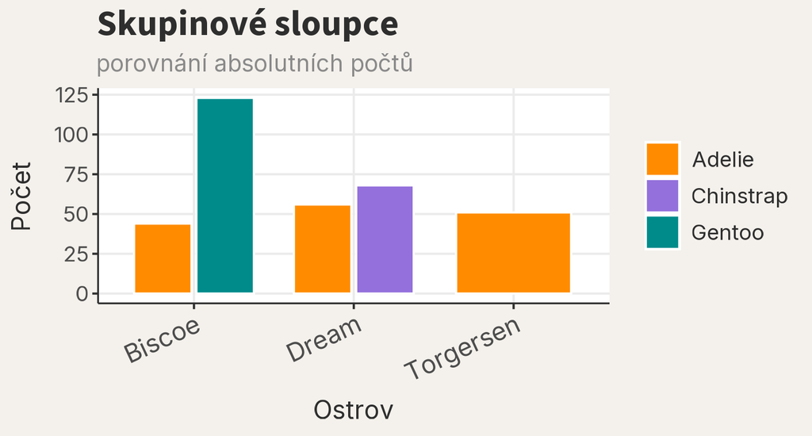

Skupinové sloupce usnadní porovnání absolutních počtů mezi ostrovy.

## Kat×Kat: skládané podíly

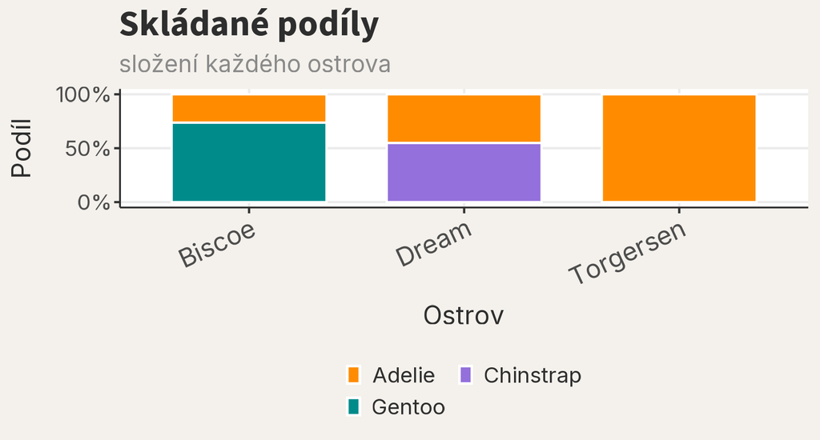

Podíly odpovídají na otázku složení, ne na otázku velikosti vzorku.